# Multiplicative Property in Bivariate Linear Model

### 6.30

When the values of y are multiplied by a constant c, from their formulas, show that sy and βˆ1 in the bivariate linear model are also then multiplied by c. Thus, show that r = βˆ1(sx/sy) does not depend on the units of measurement.

## Introduction

Consider the bivariate linear model:

$$y_i = \beta_0 + \beta_1x_i +
\varepsilon_i$$

where $y_i$ is the dependent variable, $x_i$ is the independent variable, $\beta_0$ is the intercept, $\beta_1$ is the slope coefficient, and $\varepsilon_i$ is the error term.

The formulas for $\beta_1$ (the slope coefficient), $s_y$ (standard deviation of $y$), and $s_x$ (standard deviation of $x$) are as follows:

$$\beta_1 = \frac{\sum_{i=1}^{n}(x_i -
\bar{x})(y_i - \bar{y})}{\sum_{i=1}^{n}(x_i - \bar{x})^2}$$

$$s_y = \sqrt{\frac{\sum_{i=1}^{n}(y_i -
\bar{y})^2}{n-1}}$$

$$s_x = \sqrt{\frac{\sum_{i=1}^{n}(x_i -
\bar{x})^2}{n-1}}$$

Now, let’s consider multiplying the values of $y$ by a constant $c$. The new dependent variable, let’s call it $y_c$, is given by:

$$y_c = cy$$

Now, let’s consider the new standard deviation $s_{y_c}$ of $y_c$:

$$s_{y_c} =
\sqrt{\frac{\sum_{i=1}^{n}(cy_i - \bar{cy_i})^2}{n-1}}$$

Since $c$ is a constant, it can be factored out:

$$s_{y_c} = c
\sqrt{\frac{\sum_{i=1}^{n}(y_i - \bar{y_i})^2}{n-1}}$$

Now, let’s consider the formula for $\beta_1$ in the new model with $y_c$:

$$\beta_1c = \frac{\sum_{i=1}^{n}(x_i -
\bar{x})(cy_i - \bar{cy})}{\sum_{i=1}^{n}(x_i - \bar{x})^2}$$

Again, factoring out $c$ from the numerator, resulting in $\beta_{1_c} = c \cdot \beta_1$.

$$\beta_1c = c \frac{\sum_{i=1}^{n}(x_i -
\bar{x})(y_i - \bar{y})}{\sum_{i=1}^{n}(x_i - \bar{x})^2}$$

Now, let’s consider the correlation coefficient $r$:

$$r = \frac{\text{cov}(x, y)}{s_x \cdot
s_y}$$

#### 6.42

#### (a) Simulate Data and Fit Quadratic Model

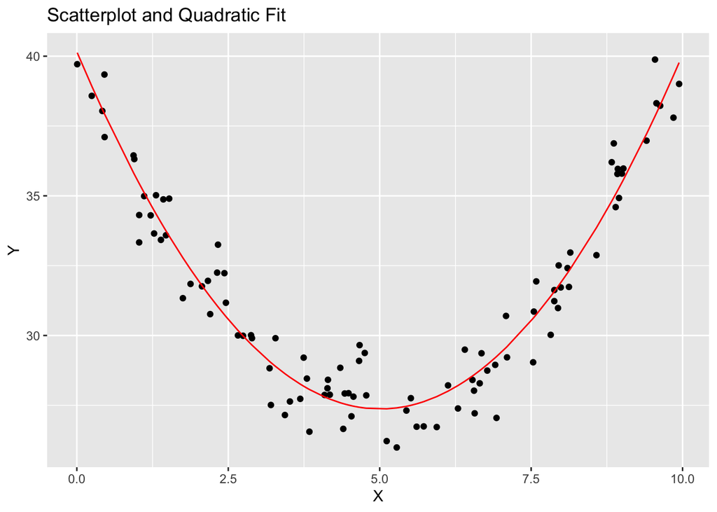

Scatterplot and Quadratic Fit

#### (b) Compare Fitted Equation with True Relationship

The true relationship is given by $Y = 40.0 - 5.0x + 0.5x^2 + \varepsilon$. Let’s compare the fitted equation with the true relationship:

```
## True Equation: Y = 40 - 5 x + 0.5 x^2 + ε
```

[output not shown]

### Task 2: Correlation and R-squared Analysis

#### (a) Find the Correlation between x and y

```
## Correlation between x and y: 0.02
```

#### (b) Explain Weak Correlation despite a Strong Relationship

The correlation between $x$ and $y$ might be weak despite a strong relationship observed in the plot because correlation measures linear relationships. In the case of a quadratic relationship, the correlation coefficient may not adequately capture the curved nature of the relationship. The correlation coefficient is a measure of linear association, and in a quadratic model, the relationship is nonlinear.

Additionally, the R-squared value for the quadratic model may be high, indicating that the model explains a large proportion of the variance in $y$, even though the linear correlation is weak.

```
## R-squared value for the quadratic model: 0.93
```

In conclusion, while the correlation between $x$ and $y$ may be weak, the quadratic model provides a good fit to the data, as indicated by the high R-squared value.